# Элементы линейной алгебры

HSE UX LAB | Анализ данных + R: мир линейных моделей, 2021

## Матрицы

## Что такое матрица?

> «Увы, невозможно объяснить, что такое матрица. Ты должен увидеть это сам.»  
> *Морфеус (Матрица, 1999)*

\[ \pmb{A}= \begin{pmatrix} 1 & 6 & 11 \\ 2 & 7 & 13 \\ 3 & 8 & 15 \\ 4 & 9 & 18 \\ 5 & 0 & 19 \end{pmatrix} \]

## Откуда берутся матрицы?

- cистема из \(n\) линейных уравнений относительно \(m\) неизвестных

\[ \begin{cases}a_{11}x_1 + a_{12}x_2 + \ldots + a_{1m}x_m = b_1 \\a_{21}x_1 + a_{22}x_2 + \ldots + a_{2m}x_m = b_2 \\ \dots \dots \dots \dots \dots \dots \dots \dots \dots \dots \\a_{n1}x_1 + a_{n2}x_2 + \ldots + a_{nm}x_m = b_n \end{cases} \]

## Матричный вид

\[ \pmb{A}\pmb{x}= \pmb{b}, \] где \[ \pmb{A}= \begin{pmatrix} a_{11} & a_{12} & \dots & a_{1m} \\ a_{21} & a_{22} & \dots & a_{2m} \\ \vdots & \vdots & \ddots & \vdots \\ a_{n1} & a_{n2} & \dots & a_{nm} \end{pmatrix} ; \quad \pmb{x}= \begin{pmatrix} x_1 \\ x_2 \\ \vdots \\ x_m \end{pmatrix} ; \quad \pmb{b}= \begin{pmatrix} b_1 \\ b_2 \\ \vdots \\ b_n \end{pmatrix} \]

\(\pmb{A}\) — матрица коэффициентов системы, \(\pmb{x}\) — вектор неизвестных, \(\pmb{b}\) — вектор свободных членов.

## Векторы

## Направленный отрезок vs набор чисел

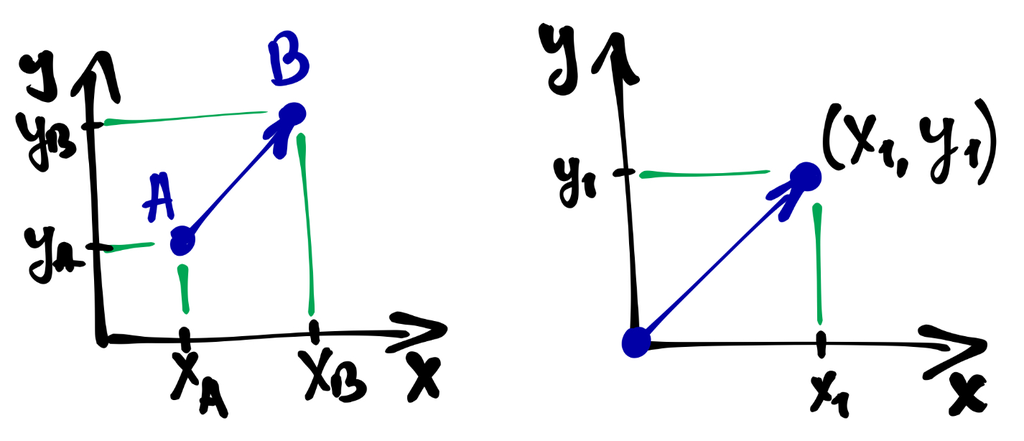

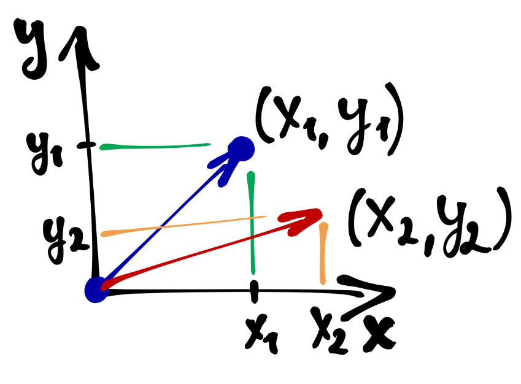

## Многомерный вектор

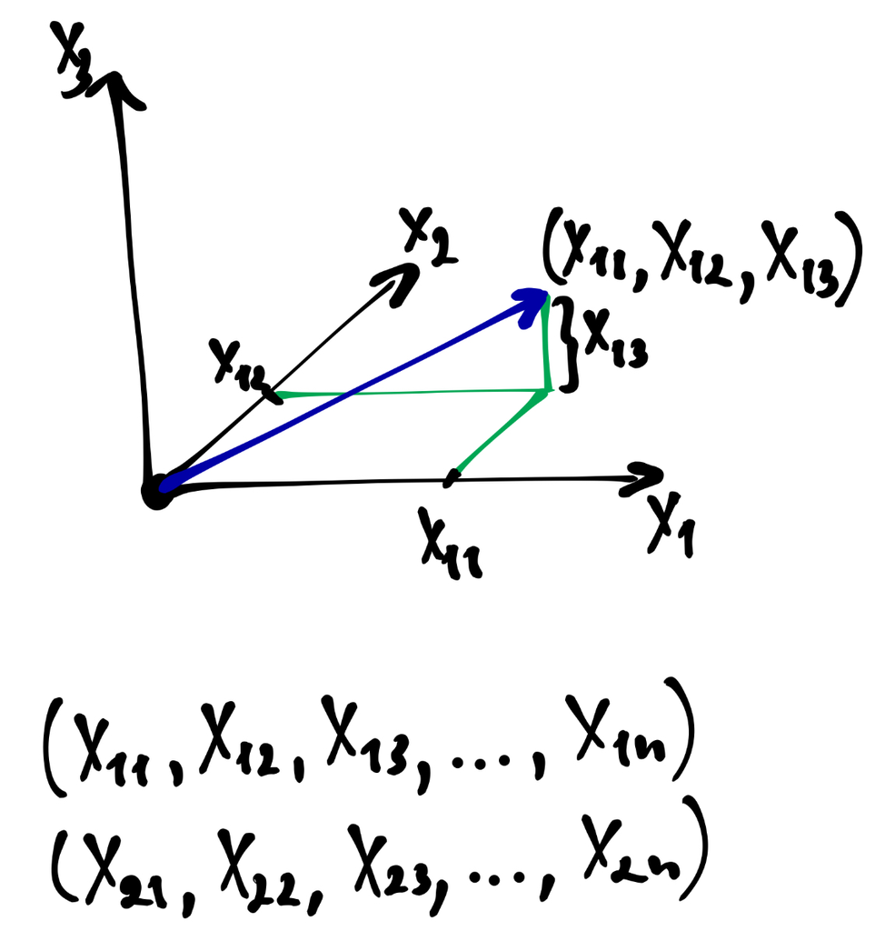

## Действия с матрицами

## Сложение матриц

\[ \pmb{A}_{n×m} + \pmb{B}_{n×m} = \begin{pmatrix} a_{11} + b_{11} & a_{12} + b_{12} & \dots & a_{1m} + b_{1m} \\ a_{21} + b_{21} & a_{22} + b_{22} & \dots & a_{2m} + b_{2m} \\ \vdots & \vdots & \ddots & \vdots \\ a_{n1} + b_{n1} & a_{n2} + b_{n2} & \dots & a_{nm} + b_{nm} \end{pmatrix} \]

**Свойства сложения матриц:**

1. \(\pmb{A}+ \pmb{B}= \pmb{B}+ \pmb{A}\) (коммутативность)
2. \((\pmb{A}+ \pmb{B}) + \pmb{C}= \pmb{A}+ (\pmb{B}+ \pmb{C})\) (ассоциативность)
3. \(\pmb{A}+ \pmb{O}= \pmb{A}\) (существование нулевого элемента)
4. \(\pmb{A}+ (-\pmb{A}) = \pmb{O}\) (существование противоположного элемента)

## Умножение матрицы на число

\[ \lambda \pmb{A}= \begin{pmatrix} \lambda a_{11} & \lambda a_{12} & \dots & \lambda a_{1m} \\ \lambda a_{21} & \lambda a_{22} & \dots & \lambda a_{2m} \\ \vdots & \vdots & \ddots & \vdots \\ \lambda a_{n1} & \lambda a_{n2} & \dots & \lambda a_{nm} \end{pmatrix}, \; \forall \lambda \in \mathbb{R} \]

**Свойства умножения матрицы на число:**

1. \(1 \cdot \pmb{A}= \pmb{A}\)
2. \(-1 \cdot \pmb{A}= -\pmb{A}\)
3. \(\lambda(\mu \pmb{A}) = (\lambda \mu) \pmb{A}\) (ассоциативность)
4. \((\lambda + \mu) \pmb{A}= \lambda \pmb{A}+ \mu \pmb{A}\) (дистрибутивность)
5. \(\lambda (\pmb{A}+ \pmb{B}) = \lambda \pmb{A}+ \lambda \pmb{B}\) (дистрибутивность)

## Скалярное произведение векторов

\[ \pmb{a}= \begin{pmatrix} a_1 & a_2 & \dots & a_n \end{pmatrix} \\ \pmb{b}= \begin{pmatrix} b_1 & b_2 & \dots & b_n \end{pmatrix}\\ \] \[ \pmb{a}\cdot \pmb{b}= a_1 b_1 + a_2 b_2 + \dots + a_n b_n = \sum_{i=1}^n a_i b_i \]

```r
a <- 1:10; b <- 10:1
a %*% b
```

```
##      [,1]
## [1,]  220
```

## Произведение матриц (матричное умножение)

\[ \pmb{A}= \begin{pmatrix} \pmb{a}_1 \\ \pmb{a}_2 \\ \vdots \\ \pmb{a}_n \end{pmatrix} = \begin{pmatrix} a_{11} & a_{12} & \dots & a_{1k} \\ a_{21} & a_{22} & \dots & a_{2k} \\ \vdots & \vdots & \ddots & \vdots \\ a_{n1} & a_{n2} & \dots & a_{nk} \end{pmatrix}, \\ \pmb{B}= \begin{pmatrix} \pmb{b}_1 & \pmb{b}_2 & \dots \pmb{b}_m \end{pmatrix} = \begin{pmatrix} b_{11} & b_{12} & \dots & b_{1m} \\ b_{21} & b_{22} & \dots & b_{2m} \\ \vdots & \vdots & \ddots & \vdots \\ b_{k1} & b_{k2} & \dots & b_{km} \end{pmatrix} \]

## Произведение матриц

\[ \pmb{A}\times \pmb{B}= \begin{pmatrix} \pmb{a}_1 \cdot \pmb{b}_1 & \pmb{a}_1 \cdot \pmb{b}_2 & \dots & \pmb{a}_1 \cdot \pmb{b}_m \\ \pmb{a}_2 \cdot \pmb{b}_1 & \pmb{a}_2 \cdot \pmb{b}_2 & \dots & \pmb{a}_2 \cdot \pmb{b}_m \\ \vdots & \vdots & \ddots & \vdots \\ \pmb{a}_n \cdot \pmb{b}_1 & \pmb{a}_n \cdot \pmb{b}_2 & \dots & \pmb{a}_n \cdot \pmb{b}_m \\ \end{pmatrix} = \]

## Произведение матриц

\[ = \begin{pmatrix} c_{11} & c_{12} & \dots & c_{1m} \\ c_{21} & c_{22} & \dots & c_{2m} \\ \vdots & \vdots & \ddots & \vdots \\ c_{n1} & c_{n2} & \dots & c_{nm} \end{pmatrix} = \pmb{C} \]

\[ c_{ij} = \sum_{t=1}^k a_{it} b_{tj} \]

## Произведение матриц

**Cвойства произведения матриц:**

1. \(\pmb{A}(\pmb{B}\pmb{C}) = (\pmb{A}\pmb{B}) \pmb{C}\) (ассоциативность)
2. \(\lambda (\pmb{A}\pmb{B}) = (\lambda \pmb{A}) \pmb{B}= (\lambda \pmb{B}) \pmb{A}\) (ассоциативность)
3. \(\pmb{A}(\pmb{B}+ \pmb{C}) = \pmb{A}\pmb{B}+ \pmb{A}\pmb{C}\) (дистрибутивность)
4. \((\pmb{A}+ \pmb{B}) \pmb{C}= \pmb{A}\pmb{C}+ \pmb{B}\pmb{C}\) (дистрибутивность)
5. \(\pmb{A}\pmb{B}\neq \pmb{B}\pmb{A}\) (отсутствие коммутативности)
6. \(\pmb{E}\pmb{A}= \pmb{A}; \, \pmb{A}\pmb{E}= \pmb{A}\) (умножение на единичный элемент)
7. \(\pmb{O}\pmb{A}= \pmb{O}; \, \pmb{A}\pmb{O}= \pmb{O}\) (умножение на нулевой элемент)
8. \(\pmb{A}\pmb{A}^{-1} = \pmb{A}^{-1} \pmb{A}= \pmb{E}\) (умножение на обратную матрицу — *только для некоторых квадратных матриц*)

## Замечательные матрицы

\[ \pmb{E}= \pmb{I}= \begin{pmatrix} 1 & 0 & \dots & 0 \\ 0 & 1 & \dots & 0 \\ \vdots & \vdots & \ddots & \vdots \\ 0 & 0 & \dots & 1 \end{pmatrix} ; \quad \pmb{O}= \begin{pmatrix} 0 & 0 & \dots & 0 \\ 0 & 0 & \dots & 0 \\ \vdots & \vdots & \ddots & \vdots \\ 0 & 0 & \dots & 0 \end{pmatrix} \]

## Транспонирование матрицы

\[ \pmb{A}= \begin{pmatrix} \pmb{a}_1 \\ \pmb{a}_2 \\ \vdots \\ \pmb{a}_n \end{pmatrix} = \begin{pmatrix} a_{11} & a_{12} & \dots & a_{1k} \\ a_{21} & a_{22} & \dots & a_{2k} \\ \vdots & \vdots & \ddots & \vdots \\ a_{n1} & a_{n2} & \dots & a_{nk} \end{pmatrix} \]

\[ \pmb{A}^\mathrm{T}= \begin{pmatrix} \pmb{a}_1 & \pmb{a}_2 & \dots & \pmb{a}_n \end{pmatrix} = \begin{pmatrix} a_{11} & a_{21} & \dots & a_{n1} \\ a_{12} & a_{22} & \dots & a_{n2} \\ \vdots & \vdots & \ddots & \vdots \\ a_{1k} & a_{2k} & \dots & a_{nk} \end{pmatrix} \]

## Детерминант матрицы и обратная матрица

\[ \pmb{A}_{n×n} \times \pmb{A}^{-1}_{n×n} = \pmb{E}_{n×n} \]

\[ \det A_{n×n} \neq 0 \Rightarrow \exists \, A^{-1}_{n×n} \\ \det A_{n×n} = 0 \Rightarrow \nexists \, A^{-1}_{n×n} \]

Одним из условий *вырожденности матрицы* является линейная зависимость строк или столбцов.

## Детерминант матрицы и обратная матрица в R

```r
A <- matrix(sample(1:10, 9, replace = TRUE), nrow = 3)
det(A)
```

```
## [1] -243
```

```r
solve(A)
```

```
##             [,1]         [,2]        [,3]
## [1,]  0.00000000 -0.111111111  0.22222222
## [2,] -0.03703704  0.251028807 -0.24279835
## [3,]  0.14814815 -0.004115226 -0.02880658
```